# ANALYZING AND PRESENTING YOUR DATA WITH R

11/18/2019

## Outline

- Introduction & news
- R and RStudio use and issues
  - Installing, updating, and alternatives
- Working with SET data
- Break
- Refresher on Status Reports
- Hacky Hour/Doctor’s Office

## Introduction & News

- Actual introductions!
- New capability in status report process: `free_y` parameter

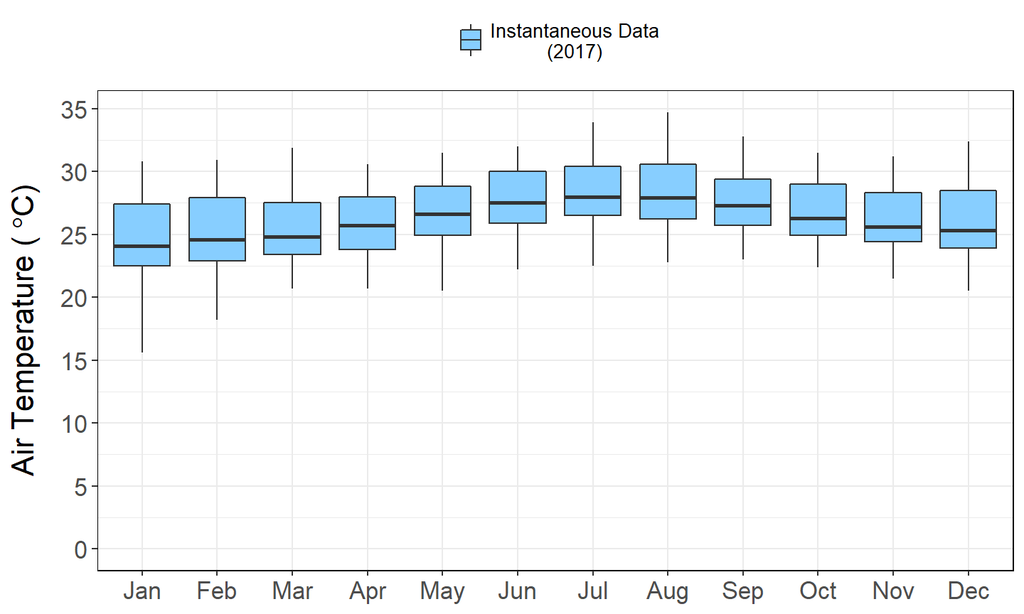

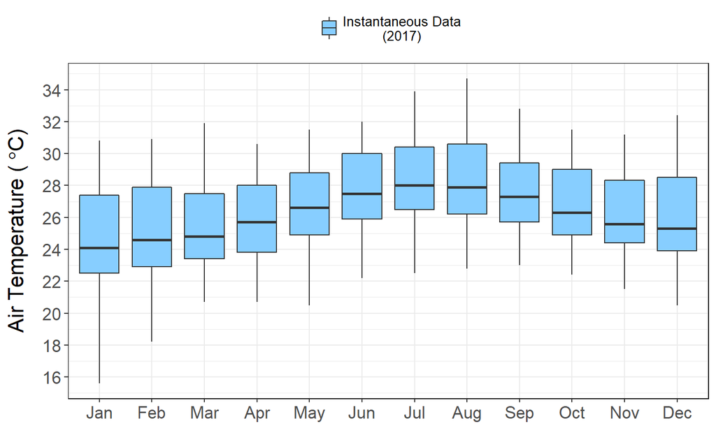

- Bug fixes to status report software
  - Metric flag works correctly
  - Error: Aesthetics must be either length 1 or the same as the data (144): label, fontface

## R and RStudio

- It is good practice to use the latest version (maybe one behind, but no more)
- Install **R**, then **RStudio**
- Updates can be out of sync
- After an update, you probably need to reload all packages
  - Definately for **R**, maybe for **RStudio**
- **Easiest way**: Source the `00_initial_installation.R` script from the `R` subdirectory of your CDMO distribution.

## Oh no! It failed!

Yeah, that happens.

- Run it again
- Run it again, again
- *Read* the error message to find the first problem package.
- For the (modestly) **BOLD**
  - Make a copy of `00_initial_installation.R` and edit out the offending package name.
  - Manually run the lines from where that package is loaded to the end of the script *(Dave demos)*
- For the less bold, but not afraid of tedium
  - Install the remaining packages one, or perhaps two, at a time

## Package Installation

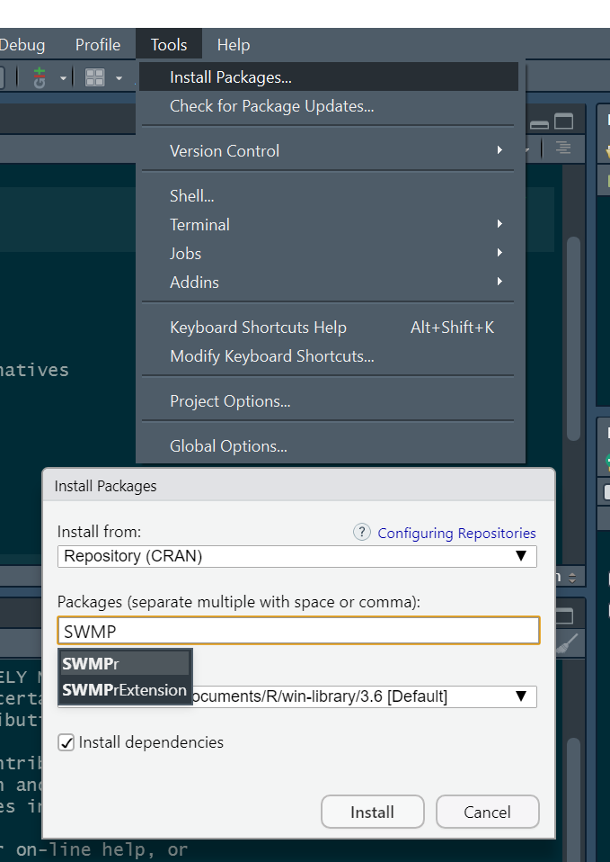

- With GUI (from CRAN)

## Package Installation

- Manually from CRAN

```
> install.packages("SWMPrExtension")
```

- Manually from GitHub
  - Gets any updates not yet pushed to CRAN

```
> install.packages("devtools")
> library(devtools)
> devtools::install_github("NOAA-OCM/SWMPrExtension")
```

Note: You specify the path after the github.com part of the package URL: “https://github.com/NOAA-OCM/SWMPrExtension” becomes **“NOAA-OCM/SWMPrExtension”**